# Updated Breathing2024 code

Riley N Derby

2024-04-18

Okay, we need to make some corrections to text files first

we need to figure a way to make sure all the .txt files are in the same format for the function that has been written

so lets reading a file of sarahs .txt and one from noah/aaron to see if we can make sarahs match.

the problem is that sarahs are one tab to left of what noahs and aarons are

```r
library(tidyverse)
sarah_example <- read_tsv("C:/Users/rnder/OneDrive/Desktop/Repos/Breathing/text_files/Bach_7-20-23_1248-Sarah.txt", col_names = F)
aaron_example <- read_tsv("C:/Users/rnder/OneDrive/Desktop/Repos/Breathing/AAS-chimps/Bach_7-20-23_1248.txt", col_names = F)
```

so, as we can see, Aarons file has 9 columns while sarahs has 8. So lets add a column to sarahs

```r
str(sarah_example)
```

```
## spc_tbl_ [17 × 8] (S3: spec_tbl_df/tbl_df/tbl/data.frame)
##  $ X1: logi [1:17] NA NA NA NA NA NA ...
##  $ X2: 'hms' num [1:17] 00:00:00 00:00:03 00:00:07 00:00:09 ...
##   ..- attr(*, "units")= chr "secs"
##  $ X3: num [1:17] 0.22 3.61 7.06 9.95 13.07 ...
##  $ X4: 'hms' num [1:17] 00:00:02 00:00:05 00:00:08 00:00:11 ...
##   ..- attr(*, "units")= chr "secs"
##  $ X5: num [1:17] 2 5.62 8.83 11.96 14.61 ...
##  $ X6: 'hms' num [1:17] 00:00:01 00:00:02 00:00:01 00:00:02 ...
##   ..- attr(*, "units")= chr "secs"
##  $ X7: num [1:17] 1.78 2 1.77 2.01 1.54 ...
##  $ X8: logi [1:17] NA NA NA NA NA NA ...
##  - attr(*, "spec")=
##   .. cols(
##   ..   X1 = col_logical(),
##   ..   X2 = col_time(format = ""),
##   ..   X3 = col_double(),
##   ..   X4 = col_time(format = ""),
##   ..   X5 = col_double(),
##   ..   X6 = col_time(format = ""),
##   ..   X7 = col_double(),
##   ..   X8 = col_logical()
##   .. )
##  - attr(*, "problems")=<externalptr>
```

```r
str(aaron_example)
```

```
## spc_tbl_ [17 × 9] (S3: spec_tbl_df/tbl_df/tbl/data.frame)
##  $ X1: chr [1:17] "default" "default" "default" "default" ...
##  $ X2: logi [1:17] NA NA NA NA NA NA ...
##  $ X3: 'hms' num [1:17] 00:00:00 00:00:03 00:00:07 00:00:10 ...
##   ..- attr(*, "units")= chr "secs"
##  $ X4: num [1:17] 0.688 3.712 7.337 10.683 13.537 ...
##  $ X5: 'hms' num [1:17] 00:00:02 00:00:05 00:00:09 00:00:12 ...
##   ..- attr(*, "units")= chr "secs"
##  $ X6: num [1:17] 2.26 5.85 9.15 12.28 14.5 ...
##  $ X7: 'hms' num [1:17] 00:00:01 00:00:02 00:00:01 00:00:01 ...
##   ..- attr(*, "units")= chr "secs"
##  $ X8: num [1:17] 1.571 2.134 1.813 1.599 0.959 ...
##  $ X9: logi [1:17] NA NA NA NA NA NA ...
##  - attr(*, "spec")=
##   .. cols(
##   ..   X1 = col_character(),
##   ..   X2 = col_logical(),
##   ..   X3 = col_time(format = ""),
##   ..   X4 = col_double(),
##   ..   X5 = col_time(format = ""),
##   ..   X6 = col_double(),
##   ..   X7 = col_time(format = ""),
##   ..   X8 = col_double(),
##   ..   X9 = col_logical()
##   .. )
##  - attr(*, "problems")=<externalptr>
```

```r
# add default column to sarahs file
sarah_example$X1_new <- as.character('default')

# Check the updated structure of sarah_example
str(sarah_example)
```

```
## spc_tbl_ [17 × 9] (S3: spec_tbl_df/tbl_df/tbl/data.frame)
##  $ X1    : logi [1:17] NA NA NA NA NA NA ...
##  $ X2    : 'hms' num [1:17] 00:00:00 00:00:03 00:00:07 00:00:09 ...
##   ..- attr(*, "units")= chr "secs"
##  $ X3    : num [1:17] 0.22 3.61 7.06 9.95 13.07 ...
##  $ X4    : 'hms' num [1:17] 00:00:02 00:00:05 00:00:08 00:00:11 ...
##   ..- attr(*, "units")= chr "secs"
##  $ X5    : num [1:17] 2 5.62 8.83 11.96 14.61 ...
##  $ X6    : 'hms' num [1:17] 00:00:01 00:00:02 00:00:01 00:00:02 ...
##   ..- attr(*, "units")= chr "secs"
##  $ X7    : num [1:17] 1.78 2 1.77 2.01 1.54 ...
##  $ X8    : logi [1:17] NA NA NA NA NA NA ...
##  $ X1_new: chr [1:17] "default" "default" "default" "default" ...
##  - attr(*, "spec")=
##   .. cols(
##   ..   X1 = col_logical(),
##   ..   X2 = col_time(format = ""),
##   ..   X3 = col_double(),
##   ..   X4 = col_time(format = ""),
##   ..   X5 = col_double(),
##   ..   X6 = col_time(format = ""),
##   ..   X7 = col_double(),
##   ..   X8 = col_logical()
##   .. )
##  - attr(*, "problems")=<externalptr>
```

```r
library(dplyr)

# Move X1_new to the first column and rename all columns
sarah_example <- sarah_example %>%
  select(X1_new, everything()) %>%
  rename(
    X1 = X1_new,
    X2 = X1,
    X3 = X2,
    X4 = X3,
    X5 = X4,
    X6 = X5,
    X7 = X6,
    X8 = X7,
    X9 = X8
  )
```

now lets create a function to read in all the txt files from sarah and correct them. We will then export the corrected files into a new folder.

ran into a slight problem in that R rounded the values when we were transforming stuff so i am going to fix that now need to stop r from rounding seconds when reading the files

```r
# use options to prevent rounding
options(digits = 15)
```

```r
library(readr)
library(dplyr)

# Function to process text files in a folder and export them
process_and_export_text_files <- function(input_folder, output_folder) {
  # Get the files from input folder
  file_list <- list.files(path = input_folder, full.names = TRUE)

  # empty list to store the processed data frames
  processed_data <- list()

  # pull each file in the input folder
  for (file_path in file_list) {
    # Read the file with specific column types to prevent rounding of milliseconds
    file_data <- read_tsv(
      file_path,
      col_names = FALSE,
      col_types = cols(
        .default = col_character(),  # default column type is character
        `X2` = col_time(format = "%H:%M:%OS"),  # Column 3 with milliseconds
        `X4` = col_time(format = "%H:%M:%OS"),  # Column 5 with milliseconds
        `X6` = col_time(format = "%H:%M:%OS")   # Column 7 with milliseconds
      )
    )

    # Add 'default' column
    file_data$X1_new <- 'default'

    # Reorder and rename
    file_data <- file_data %>%
      select(X1_new, everything()) %>%
      rename(X1 = X1_new, X2 = X1, X3 = X2, X4 = X3, X5 = X4, X6 = X5, X7 = X6, X8 = X7, X9 = X8)

    # make list
    processed_data[[file_path]] <- file_data

    # create output file path
    output_file <- paste0(output_folder, "/", basename(file_path))

    # Export
    write_tsv(file_data, output_file, col_names = FALSE)
  }

  # Return the list of processed data frames
  return(processed_data)
}
```

```r
# input and output folder paths
input_folder <- "C:/Users/rnder/OneDrive/Desktop/Repos/Breathing/text_files/"
output_folder <- "C:/Users/rnder/OneDrive/Desktop/Repos/Breathing/text_files_2/"

# Process and export text files from the input folder to the output folder
processed_files <- process_and_export_text_files(input_folder, output_folder)
```

now that they are in correct format lets create files with data we want so we can analyze breathing rates

```r
# Function to convert HH:MM:SS to seconds
convert_to_seconds <- function(time_str) {
  time_str <- as.character(time_str)  # Ensure the input is treated as a character
  parts <- unlist(strsplit(time_str, split = ":"))
  return(as.numeric(parts[1]) * 3600 + as.numeric(parts[2]) * 60 + as.numeric(parts[3]))
}

# Function to process each file
process_file <- function(file_path, observer) {
  # Check if file is empty or doesn't exist
  if (!file.exists(file_path) || file.info(file_path)$size == 0) {
    warning(sprintf("File '%s' is empty or doesn't exist.", file_path))
    return(NULL)
  }

  # Read the data
  data <- read.table(file_path, header = FALSE, sep = "\t", fill = TRUE)

  # Check if data has been read correctly
  if (nrow(data) == 0) {
    warning(sprintf("No data in file '%s'.", file_path))
    return(NULL)
  }

  # Convert time columns to seconds
  data$V3_sec <- sapply(data$V3, convert_to_seconds, USE.NAMES = FALSE)
  data$V5_sec <- sapply(data$V5, convert_to_seconds, USE.NAMES = FALSE)
  data$V7_sec <- sapply(data$V7, convert_to_seconds, USE.NAMES = FALSE)

  # Calculate metrics
  total_duration_sec <- max(data$V5_sec, na.rm = TRUE) - min(data$V3_sec, na.rm = TRUE)
  breaths_per_minute <- nrow(data) / (total_duration_sec / 60)
  mean_breath_duration <- mean(data$V7_sec, na.rm = TRUE)
  RR_intervals <- diff(data$V3_sec)
  RRI_variability <- sd(RR_intervals, na.rm = TRUE)

  # Extract the file name
  file_name <- gsub("\\.txt$", "", basename(file_path))

  # Return the results as a data frame
  return(data.frame(
    Observer = observer,
    File_Name = file_name,
    Total_Duration_seconds = total_duration_sec,
    Breaths_Per_Minute = breaths_per_minute,
    Mean_Breath_Duration = mean_breath_duration,
    RRI_Variability = RRI_variability
  ))
}

# Define the directories
directories <- list(
  AAS = "C:/Users/rnder/OneDrive/Desktop/Repos/Breathing/AAS-chimps",
  STX = "C:/Users/rnder/OneDrive/Desktop/Repos/Breathing/text_files_2"
)

# empty data frame for the results
all_results <- data.frame()

# Loop through each directory
for (observer in names(directories)) {
  directory <- directories[[observer]]
  files <- list.files(directory, pattern = "\\.txt$", full.names = TRUE)

  # Loop through the files and process each one
  for (file in files) {
    file_results <- process_file(file, observer)
    all_results <- rbind(all_results, file_results)
  }
}

# Extract the name from the File_Name
all_results$Name <- sub("^([^_ ]+)[_ ].*$", "\\1", all_results$File_Name)

breathing_data_chimps1 <- all_results
```

compare two coders

```r
# First, let's split the data by observer
data_AAS <- breathing_data_chimps1 %>% filter(Observer == "AAS")
data_STX <- breathing_data_chimps1 %>% filter(Observer == "STX")

#remove '-Sarah' from end of file names in data_stx
data_STX$File_Name <- gsub("-Sarah$", "", data_STX$File_Name)

# Now, let's find the common filenames
common_files <- intersect(data_AAS$File_Name, data_STX$File_Name)

# Filter data to only include these common filenames
data_AAS_common <- data_AAS %>% filter(File_Name %in% common_files)
data_STX_common <- data_STX %>% filter(File_Name %in% common_files)

# Merge the common data from both observers
comparison_data <- merge(data_AAS_common, data_STX_common, by = "File_Name", suffixes = c("_AAS", "_STX"))

# Now you have a data frame where you can compare the metrics between the two observers
# Let's compare the Breaths_Per_Minute as an example
comparison_data %>%
  select(File_Name, Breaths_Per_Minute_AAS, Breaths_Per_Minute_STX) %>%
  mutate(Difference = Breaths_Per_Minute_AAS - Breaths_Per_Minute_STX) %>%
  arrange(desc(Difference))
```

```
##               File_Name Breaths_Per_Minute_AAS Breaths_Per_Minute_STX
## 1  Buckner_23-6-14_1427       19.2058385749268       17.6908128392414
## 2    Cedar_23-5-29_1729       20.6856923960927       19.6157618415739
## 3 BobiWine_7-17-23_1403       21.0368329109564       20.3404874320443
## 4    Cedar_23-5-29_1734       19.2059339713236       18.9445490870687
## 5     Bach_7-20-23_1248       19.3702761213871       19.2834861518102
## 6  Buckner_7-15-23_0912       19.6689067366006       19.6228060612668
## 7 BobiWine_7-17-23_1356       23.6754147066105       23.6633311165071
## 8     Bach_7-20-23_1258       19.0530309361055       19.0498470999114
##            Difference
## 1 1.51502573568533450
## 2 1.06993055451882313
## 3 0.69634547891209664
## 4 0.26138488425484496
## 5 0.08678996957687701
## 6 0.04610067533379691
## 7 0.01208359010344395
## 8 0.00318383619405793
```

```r
# You can also calculate correlation or other statistics based on the comparison
```

```r
# Calculate Pearson correlation ie normally distributed data
cor.test(comparison_data$Breaths_Per_Minute_AAS, comparison_data$Breaths_Per_Minute_STX, method = "pearson")
```

```
##
##  Pearson's product-moment correlation
##
## data:  comparison_data$Breaths_Per_Minute_AAS and comparison_data$Breaths_Per_Minute_STX
## t = 7.112239727256, df = 6, p-value = 0.000388417154435
## alternative hypothesis: true correlation is not equal to 0
## 95 percent confidence interval:
##  0.721601071077916 0.990339788158587
## sample estimates:
##               cor
## 0.945496098039193
```

```r
# Calculate Spearman correlation ie non-normally distributed data
cor.test(comparison_data$Breaths_Per_Minute_AAS, comparison_data$Breaths_Per_Minute_STX, method = "spearman")
```

```
##
##  Spearman's rank correlation rho
##
## data:  comparison_data$Breaths_Per_Minute_AAS and comparison_data$Breaths_Per_Minute_STX
## S = 8, p-value = 0.00456349206349
## alternative hypothesis: true rho is not equal to 0
## sample estimates:
##               rho
## 0.904761904761905
```

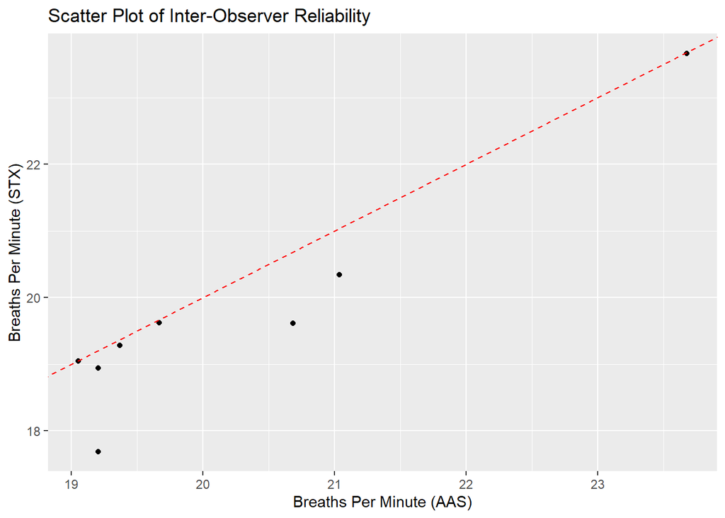

```r
library(ggplot2)

# Scatter plot with a line of perfect agreement
ggplot(comparison_data, aes(x = Breaths_Per_Minute_AAS, y = Breaths_Per_Minute_STX)) +
  geom_point() +
  geom_abline(intercept = 0, slope = 1, linetype = "dashed", color = "red") +
  xlab("Breaths Per Minute (AAS)") +
  ylab("Breaths Per Minute (STX)") +
  ggtitle("Scatter Plot of Inter-Observer Reliability")
```

```r
library(irr)
# Calculate ICC
icc <- icc(cbind(comparison_data$Breaths_Per_Minute_AAS, comparison_data$Breaths_Per_Minute_STX), model = "twoway", type = "agreement")
print(icc)
```

```
##  Single Score Intraclass Correlation
##
##    Model: twoway
##    Type : agreement
##
##    Subjects = 8
##      Raters = 2
##    ICC(A,1) = 0.912
##
##  F-Test, H0: r0 = 0 ; H1: r0 > 0
##   F(7,4.56) = 32.5 , p = 0.00118
##
##  95%-Confidence Interval for ICC Population Values:
##   0.517 < ICC < 0.983
```

Now I want to load in breathing we coded in the field

```r
library(dplyr)

ngogo <- read.csv("C:/Users/rnder/OneDrive/Desktop/Repos/Breathing/Breathing2023-AAS-chimps-editing.csv")

# Filter out rows where RR is not NA
ngogoRR <- ngogo %>% filter(!is.na(RR) & RR > 0)

# Create the new 'Name' column by extracting the text before '_' or ','
ngogoRR$Name <- sub("_.*", "", ngogoRR$IndividualID) # Remove anything after the underscore
ngogoRR$Name <- sub(",.*", "", ngogoRR$Name)      # Remove anything after the comma


# View the first few rows of the filtered dataframe
head(ngogoRR)
```

```
##            Filename.      Date        Time IndividualID Breaths Time.1      RR
## 1                    7/18/2023 11:55:38 AM        Bosko      18     60 18.0000
## 2                    7/18/2023 12:03:47 PM        Bosko      18     60 18.0000
## 3                    7/18/2023 12:10:39 PM        Bosko      20     60 20.0000
## 4                    7/19/2023 11:58:37 AM        Bosko      10     37 16.2162
## 5 Bosko_7-17-23_1325 7/17/2023  1:25:26 PM       Bosko,      20     60 20.0000
## 6 Bowie_7-20-23_1222 7/20/2023 12:22:00 PM       Bowie,      13     30 26.0000
##       Current         ID0                                  Prox0 Prior1
## 1        Rest
## 2        Rest
## 3        Rest                                                      Rest
## 4        Rest                                     PucciniPuccini   Rest
## 5      RecGr, Cannonball,            Cannonball,Puccini,Woodrow, RecGr,
## 6 Rest.Relax,             Buckner,Hutcherson,Wes,YoYo,Justine_2,  Rest,
##        ID1 Prior5           ID5       Prior15                ID15 PartyCurrent
```

[output cut: 27 more lines]

load demography

```r
ngogoDemog <- read.csv("C:/Users/rnder/OneDrive/Desktop/Repos/Breathing/demographyForNetworks_22.csv")

ngogoDemog1 <- ngogoDemog %>% select(Name = individualID, Sex, DOB = DOB, mother, father)

ngogoRR <- left_join(ngogoRR, ngogoDemog1, by = "Name")

ngogoRR$Date <- as.Date(ngogoRR$Date, format="%m/%d/%y")
ngogoRR$DOB <- as.Date(ngogoRR$DOB, format="%m/%d/%y")

# Calculate age in years as the difference between the dates
ngogoRR$Age <- as.numeric(difftime(ngogoRR$Date, ngogoRR$DOB, units="weeks")) / 52.1775

# Round the age to the nearest 0.5 years
ngogoRR$Age_rounded <- round(ngogoRR$Age * 2) / 2
```

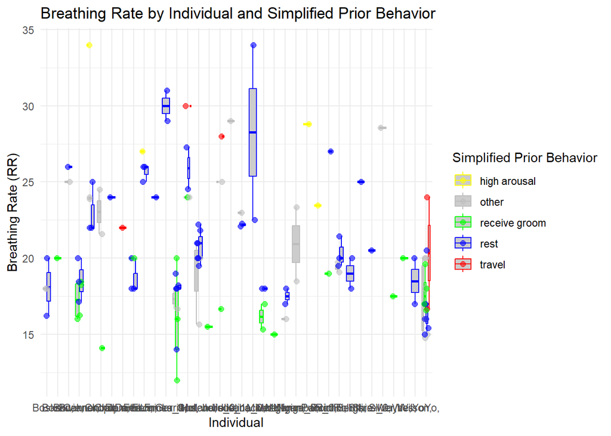

```r
# Create a new column 'Prior1b' with simplified behavior categories
ngogoRR$Prior1b <- sapply(ngogoRR$Prior1, function(x) {
  if (grepl("Rest|Rest.Relax|Rest.Alert", x)) {
    "rest"
  } else if (grepl("RecGr|RecGroom", x)) {
    "receive groom"
  } else if (grepl("PantHoot|PiloErection|RecDisplay|Copulate", x)) {
    "high arousal"
  } else if (grepl("Climb|Travel", x)) {
    "travel"
  } else if (x %in% c("Feed", "", "SelfGr")) {
    "other"
  } else {
    "other" # Default category if none of the above conditions are met
  }
})

# Now, let's create the boxplot with this new categorization

library(ggplot2)

# Filter out rows where 'RR' is NA
filtered_ngogoRR <- ngogoRR %>% filter(!is.na(RR))

# color palette for the 'Prior1b' behaviors
behavior_colors <- scale_color_manual(values = c(
  "rest" = "blue",
  "receive groom" = "green",
  "high arousal" = "yellow",
  "travel" = "red",
  "other" = "grey"
))

# Create the boxplot
ggplot(filtered_ngogoRR, aes(x = IndividualID, y = RR, color = Prior1b)) +
  geom_boxplot(outlier.shape = NA, fill = "grey80") +  # Grey boxplots
  geom_jitter(width = 0.2, size = 2, alpha = 0.6) +    # Jittered points for individual observations
  behavior_colors +                                    # Apply custom colors for behaviors
  theme(axis.text.x = element_text(angle = 90, hjust = 1)) + # Rotate x-axis labels for readability
  labs(title = "Breathing Rate by Individual and Simplified Prior Behavior",
       x = "Individual",
       y = "Breathing Rate (RR)",
       color = "Simplified Prior Behavior") +
  theme_minimal()  # Minimal theme for a clean look
```

```r
# Note: Adjust the color palette based on the actual behaviors in your dataset
```

just rest with other behaviors overlaid

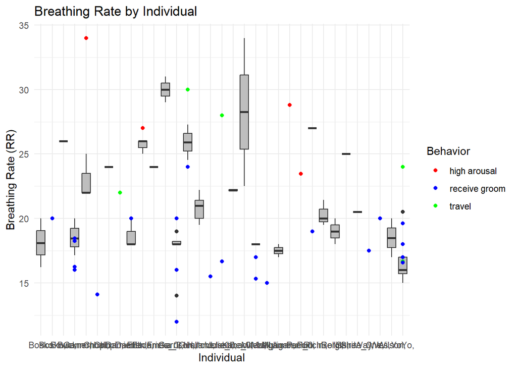

```r
# Filter the data for the 'rest' behavior
rest_data <- ngogoRR[ngogoRR$Prior1b == "rest", ]

# Filter the data for the other behaviors
other_behaviors <- ngogoRR %>%
  filter(Prior1b %in% c("receive groom", "high arousal", "travel"))

# Create the boxplot with gray boxes for 'rest' behavior
p <- ggplot() +
  geom_boxplot(data = rest_data, aes(x = IndividualID, y = RR), fill = "gray") +
  geom_point(data = other_behaviors, aes(x = IndividualID, y = RR, color = Prior1b)) +
  scale_color_manual(values = c("receive groom" = "blue", "high arousal" = "red", "travel" = "green")) +
  theme(axis.text.x = element_text(angle = 45, vjust = 1, hjust = 1)) +
  labs(title = "Breathing Rate by Individual",
       x = "Individual",
       y = "Breathing Rate (RR)",
       color = "Behavior") +
  theme_minimal() +
  theme(legend.position = "right") # Adjust legend position

# Print the plot
print(p)
```

Trying to make names legible

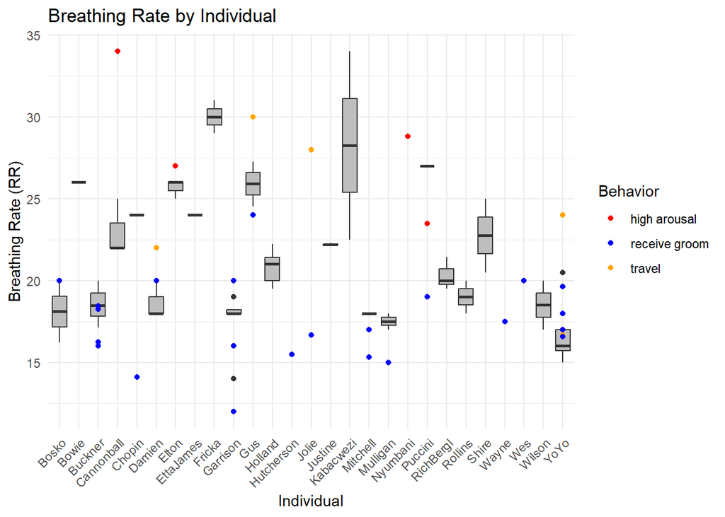

```r
# Filter the data for the 'rest' behavior
rest_data <- ngogoRR[ngogoRR$Prior1b == "rest", ]

# Filter the data for the other behaviors
other_behaviors <- ngogoRR %>%
  filter(Prior1b %in% c("receive groom", "high arousal", "travel"))

# Create the boxplot with gray boxes for 'rest' behavior
p <- ggplot() +
  geom_boxplot(data = rest_data, aes(x = Name, y = RR), fill = "gray") +
  geom_point(data = other_behaviors, aes(x = Name, y = RR, color = Prior1b)) +
  scale_color_manual(values = c("receive groom" = "blue", "high arousal" = "red", "travel" = "orange")) +
  labs(title = "Breathing Rate by Individual",
       x = "Individual",
       y = "Breathing Rate (RR)",
       color = "Behavior") +
  theme_minimal() +
  theme(legend.position = "right", # Adjust legend position
        axis.text.x = element_text(angle = 45, vjust = 1, hjust = 1)) # Adjust text angle

# Print the plot
print(p)
```

Now I want to sort by age

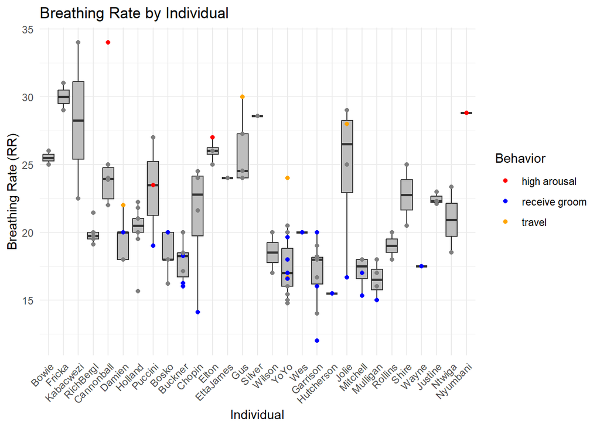

```r
library(ggplot2)
library(dplyr)

ngogoRR_sorted <- ngogoRR[order(ngogoRR$Age_rounded), ]

# Create the boxplot with the reordered factor
ggplot(ngogoRR_sorted, aes(x = reorder(Name, Age_rounded), y = RR)) +
  geom_boxplot(fill = "gray") +
  geom_point(aes(color = Prior1b)) +
  scale_color_manual(values = c("receive groom" = "blue", "high arousal" = "red", "travel" = "orange")) +
  labs(title = "Breathing Rate by Individual",
       x = "Individual",
       y = "Breathing Rate (RR)",
       color = "Behavior") +
  theme_minimal() +
  theme(legend.position = "right", # Adjust legend position
        axis.text.x = element_text(angle = 45, vjust = 1, hjust = 1)) # Adjust text angle
```

another looked based on sex

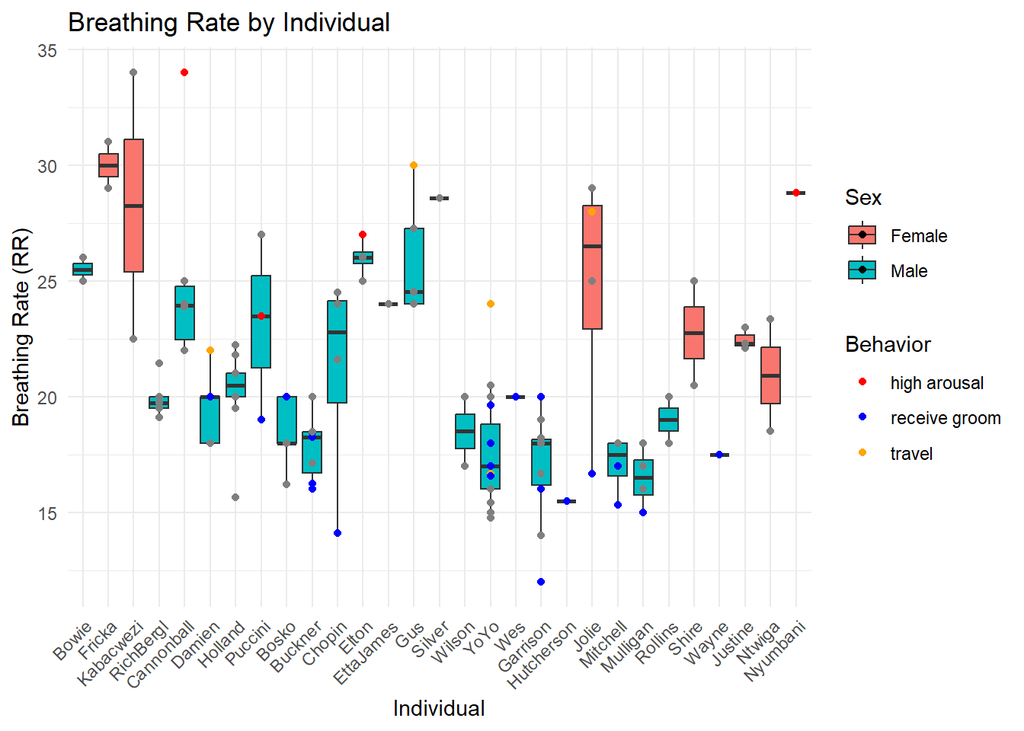

```r
ggplot(ngogoRR_sorted, aes(x = reorder(Name, Age_rounded), y = RR, fill = Sex)) +
    geom_boxplot() +
  geom_point(aes(color = Prior1b)) +
  scale_color_manual(values = c("receive groom" = "blue", "high arousal" = "red", "travel" = "orange")) +
  labs(title = "Breathing Rate by Individual",
       x = "Individual",
       y = "Breathing Rate (RR)",
       color = "Behavior") +
  theme_minimal() +
  theme(legend.position = "right", # Adjust legend position
        axis.text.x = element_text(angle = 45, vjust = 1, hjust = 1)) # Adjust text angle
```

Okay, lets do some simple statistical analyses to see if there is differences in category. Since we have low sample size on certain behaviors, I want to combine high arousal and travel breathing rates into one category.

I will determine if high arousal/travel mean breathing rate is different than resting breathing rate and receive groom breathing rate across this sample.

To do this, I want to take means of each category as test statistic. Creating 95% confidence interval using bootstrap pulling from sample and then conducting an anova.

```r
#lets start by separating the dataset based on Prior1b values so we can easily calculate means
rest_data <- ngogoRR %>% filter(Prior1b == "rest")
receive_groom_data <- ngogoRR %>% filter(Prior1b == "receive groom")
travel_high_arousal_data <- ngogoRR %>% filter(Prior1b %in% c("travel", "high arousal"))
```

```r
library(dplyr)
library(tidyr)
library(purrr)
library(broom)
library(ggplot2)

# Calculate mean breathing rate for each category
mean_rest <- ngogoRR %>%
  filter(Prior1b == "rest") %>%
  summarize(mean_breathing_rate = mean(RR, na.rm = TRUE))

mean_receive_groom <- ngogoRR %>%
  filter(Prior1b == "receive groom") %>%
  summarize(mean_breathing_rate = mean(RR, na.rm = TRUE))

mean_travel_high_arousal <- ngogoRR %>%
  filter(Prior1b %in% c("travel", "high arousal")) %>%
  summarize(mean_breathing_rate = mean(RR, na.rm = TRUE))

# Combine means into one dataframe
means_df <- rbind(mean_rest, mean_receive_groom, mean_travel_high_arousal)

# Add a category column
means_df$Category <- c("Rest", "Receive Groom", "Travel/High Arousal")
```

rest bootstrap

```r
# okay now lets do bootstraps for 3 categories starting with rest
bootstrap_ci <- function(data, variable, n_bootstraps = 1000, alpha = 0.05) {
  boot_means <- replicate(n_bootstraps, {
    sample_data <- sample_n(data, size = nrow(data), replace = TRUE)
    mean_val <- mean(sample_data[[variable]], na.rm = TRUE)
    return(mean_val)
  })

  ci_lowerR <- quantile(boot_means, alpha / 2)
  ci_upperR <- quantile(boot_means, 1 - alpha / 2)

  return(list(ci_lowerR = ci_lowerR, ci_upperR = ci_upperR, boot_means = boot_means))
}

# Bootstrap for the "Rest" category
bootstrap_results_rest <- bootstrap_ci(rest_data, "RR")
```

receive groom bootstrap

```r
bootstrap_ci <- function(data, variable, n_bootstraps = 1000, alpha = 0.05) {
  boot_means <- replicate(n_bootstraps, {
    sample_data <- sample_n(data, size = nrow(data), replace = TRUE)
    mean_val <- mean(sample_data[[variable]], na.rm = TRUE)
    return(mean_val)
  })

  ci_lowerRG <- quantile(boot_means, alpha / 2)
  ci_upperRG <- quantile(boot_means, 1 - alpha / 2)

  return(list(ci_lowerRG = ci_lowerRG, ci_upperRG = ci_upperRG, boot_means = boot_means))
}

# Bootstrap for the "receive groom" category
bootstrap_results_RG <- bootstrap_ci(receive_groom_data, "RR")
```

high arousal/travel bootstrap

```r
bootstrap_ci <- function(data, variable, n_bootstraps = 1000, alpha = 0.05) {
  boot_means <- replicate(n_bootstraps, {
    sample_data <- sample_n(data, size = nrow(data), replace = TRUE)
    mean_val <- mean(sample_data[[variable]], na.rm = TRUE)
    return(mean_val)
  })

  ci_lowerTHA <- quantile(boot_means, alpha / 2)
  ci_upperTHA <- quantile(boot_means, 1 - alpha / 2)

  return(list(ci_lowerTHA = ci_lowerTHA, ci_upperTHA = ci_upperTHA, boot_means = boot_means))
}

# Bootstrap for the "travel/high arousal" category
bootstrap_results_travel_HA <- bootstrap_ci(travel_high_arousal_data, "RR")
```

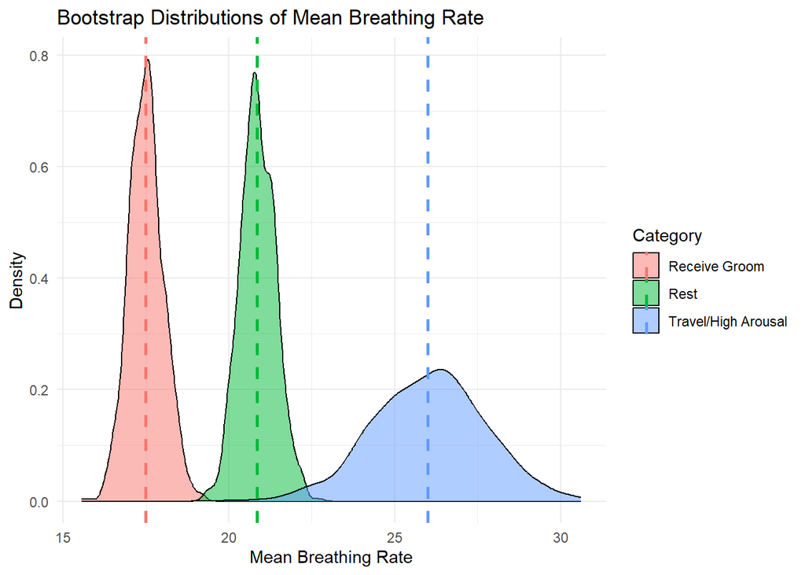

```r
library(ggplot2)

# Create a dataframe for plotting the bootstrap distributions
bootstrap_df <- data.frame(
  Category = c(rep("Rest", length(bootstrap_results_rest$boot_means)),
               rep("Receive Groom", length(bootstrap_results_RG$boot_means)),
               rep("Travel/High Arousal", length(bootstrap_results_travel_HA$boot_means))),
  Bootstrapped_Mean = c(bootstrap_results_rest$boot_means,
                        bootstrap_results_RG$boot_means,
                        bootstrap_results_travel_HA$boot_means)
)

# Plot the distributions with means marked
ggplot(bootstrap_df, aes(x = Bootstrapped_Mean, fill = Category)) +
  geom_density(alpha = 0.5) +
  geom_vline(aes(xintercept = mean_breathing_rate, color = Category),
             data = means_df, linetype = "dashed", size = 1) +
  labs(title = "Bootstrap Distributions of Mean Breathing Rate",
       x = "Mean Breathing Rate",
       y = "Density",
       color = "Category",
       fill = "Category") +
  theme_minimal()
```

```r
# Add confidence interval values to means_df
means_df$ci_lower <- c(bootstrap_results_rest$ci_lowerR, bootstrap_results_RG$ci_lowerRG, bootstrap_results_travel_HA$ci_lowerTHA)
means_df$ci_upper <- c(bootstrap_results_rest$ci_upperR, bootstrap_results_RG$ci_upperRG, bootstrap_results_travel_HA$ci_upperTHA)
means_df$sd <- c(sd(rest_data$RR), sd(receive_groom_data$RR), sd(travel_high_arousal_data$RR))
means_df$var <- c(var(rest_data$RR), var(receive_groom_data$RR), var(travel_high_arousal_data$RR))

means_df
```

```
##   mean_breathing_rate            Category         ci_lower         ci_upper
## 1    20.8560365900000                Rest 19.8898520565086 21.9532301142845
## 2    17.4896805065217       Receive Groom 16.5258711002391 18.5489706915326
## 3    25.9942555555556 Travel/High Arousal 22.5352230555556 29.3118841666667
##                 sd              var
## 1 4.06342516861119 16.5114241009029
## 2 2.52750340487545  6.3882734616570
## 3 5.07749413961038 25.7809467377778
```

okay, now lets do an ANOVA and kruskal wallace with raw data

```r
combined_data <- rbind(rest_data, receive_groom_data, travel_high_arousal_data)
combined_data <- combined_data %>%
  mutate(Prior1b = ifelse(Prior1b %in% c("high arousal", "travel"), "higharousal_travel", Prior1b))

# Perform ANOVA test
anova_result <- aov(RR ~ Prior1b, data = combined_data)

summary(anova_result)
```

```
##             Df         Sum Sq        Mean Sq  F value    Pr(>F)
## Prior1b      2  487.452097187 243.7260485937 16.46362 8.633e-07 ***
## Residuals   87 1287.940763810  14.8039168254
## ---
## Signif. codes:  0 '***' 0.001 '**' 0.01 '*' 0.05 '.' 0.1 ' ' 1
```

```r
tukey_result <- TukeyHSD(anova_result)
tukey_result
```

```
##   Tukey multiple comparisons of means
##     95% family-wise confidence level
##
## Fit: aov(formula = RR ~ Prior1b, data = combined_data)
##
## $Prior1b
##                                               diff                lwr
## receive groom-higharousal_travel -8.50457504903382 -12.11178768859070
## rest-higharousal_travel          -5.13821896555555  -8.42510069617583
## rest-receive groom                3.36635608347827   1.10563740642398
##                                                upr             p adj
## receive groom-higharousal_travel -4.89736240947695 0.000000670404273
## rest-higharousal_travel          -1.85133723493527 0.000992489945102
## rest-receive groom                5.62707476053256 0.001786616351574
```

```r
# Perform Kruskal-Wallis test
kruskal_test_result <- kruskal.test(RR ~ Prior1b, data = combined_data)
kruskal_test_result
```

```
##
##  Kruskal-Wallis rank sum test
##
## data:  RR by Prior1b
## Kruskal-Wallis chi-squared = 22.47643112179, df = 2, p-value =
## 1.31614881007e-05
```

lets do anova with bootstrapped data

```r
# Perform ANOVA using bootstrapped means
anova_result_boot <- aov(Bootstrapped_Mean ~ Category, data = bootstrap_df)

# Perform Tukey HSD post-hoc test using bootstrapped means
tukey_result_boot <- TukeyHSD(anova_result_boot)
tukey_result_boot
```

```
##   Tukey multiple comparisons of means
##     95% family-wise confidence level
##
## Fit: aov(formula = Bootstrapped_Mean ~ Category, data = bootstrap_df)
##
## $Category
##                                               diff              lwr
## Rest-Receive Groom                3.36365892878419 3.25246800621871
## Travel/High Arousal-Receive Groom 8.52347506414917 8.41228414158368
## Travel/High Arousal-Rest          5.15981613536497 5.04862521279949
##                                                upr p adj
## Rest-Receive Groom                3.47484985134968     0
## Travel/High Arousal-Receive Groom 8.63466598671465     0
## Travel/High Arousal-Rest          5.27100705793046     0
```

It looks like the means of all 3 categories are statistically different from one another.

lets do a t test now

```r
#recall separated datasets
#rest_data
#receive_groom_data
#travel_high_arousal_data


# Perform two-sample t-test
t_test_HRvR <- t.test(travel_high_arousal_data$RR, rest_data$RR)
t_test_HRvR
```

```
##
##  Welch Two Sample t-test
##
## data:  travel_high_arousal_data$RR and rest_data$RR
## t = 2.895412611643, df = 9.655711455663, p-value = 0.0165185675643
## alternative hypothesis: true difference in means is not equal to 0
## 95 percent confidence interval:
##  1.16495424716771 9.11148368394340
## sample estimates:
##        mean of x        mean of y
## 25.9942555555556 20.8560365900000
```

```r
t_test_HRvRG <- t.test(travel_high_arousal_data$RR, receive_groom_data$RR)
t_test_HRvRG
```

```
##
##  Welch Two Sample t-test
##
## data:  travel_high_arousal_data$RR and receive_groom_data$RR
## t = 4.797652074966, df = 9.593797512736, p-value = 0.000816124990518
## alternative hypothesis: true difference in means is not equal to 0
## 95 percent confidence interval:
##   4.53207099714481 12.47707910092281
## sample estimates:
##        mean of x        mean of y
## 25.9942555555556 17.4896805065217
```

```r
t_test_RvRG <- t.test(rest_data$RR, receive_groom_data$RR)
t_test_RvRG
```

```
##
##  Welch Two Sample t-test
##
## data:  rest_data$RR and receive_groom_data$RR
## t = 4.488751110206, df = 64.1845532809, p-value = 3.04338031008e-05
## alternative hypothesis: true difference in means is not equal to 0
## 95 percent confidence interval:
##  1.86823404086155 4.86447812609497
## sample estimates:
##        mean of x        mean of y
## 20.8560365900000 17.4896805065217
```

```r
## now lets do with bootstrap distributions

#recall bootstrapped file
#bootstrap_df

# t-tests
# Filter the bootstrap_df for each category
rest_bootstrap <- bootstrap_df[bootstrap_df$Category == "Rest", ]
receive_groom_bootstrap <- bootstrap_df[bootstrap_df$Category == "Receive Groom", ]
travel_high_arousal_bootstrap <- bootstrap_df[bootstrap_df$Category == "Travel/High Arousal", ]

# Perform t-tests for each category
t_test_boot_RvRG <- t.test(rest_bootstrap$Bootstrapped_Mean, receive_groom_bootstrap$Bootstrapped_Mean)
t_test_boot_RvRG
```

```
##
##  Welch Two Sample t-test
##
## data:  rest_bootstrap$Bootstrapped_Mean and receive_groom_bootstrap$Bootstrapped_Mean
## t = 142.2981144497, df = 1997.026072352, p-value < 2.220446049e-16
## alternative hypothesis: true difference in means is not equal to 0
## 95 percent confidence interval:
##  3.31730098187135 3.41001687569674
## sample estimates:
##        mean of x        mean of y
## 20.8675783646353 17.5039194358513
```

```r
t_test_boot_HRvR <- t.test(travel_high_arousal_bootstrap$Bootstrapped_Mean, rest_bootstrap$Bootstrapped_Mean)
t_test_boot_HRvR
```

```
##
##  Welch Two Sample t-test
##
## data:  travel_high_arousal_bootstrap$Bootstrapped_Mean and rest_bootstrap$Bootstrapped_Mean
## t = 92.67887067337, df = 1199.675955174, p-value < 2.220446049e-16
## alternative hypothesis: true difference in means is not equal to 0
## 95 percent confidence interval:
##  5.05058663134336 5.26904563938595
## sample estimates:
##        mean of x        mean of y
## 26.0273945000000 20.8675783646353
```

```r
t_test_boot_HRvRG <- t.test(travel_high_arousal_bootstrap$Bootstrapped_Mean, receive_groom_bootstrap$Bootstrapped_Mean)
t_test_boot_HRvRG
```

```
##
##  Welch Two Sample t-test
##
## data:  travel_high_arousal_bootstrap$Bootstrapped_Mean and receive_groom_bootstrap$Bootstrapped_Mean
## t = 153.4014222286, df = 1191.169745231, p-value < 2.220446049e-16
## alternative hypothesis: true difference in means is not equal to 0
## 95 percent confidence interval:
##  8.41446241107021 8.63248771722717
## sample estimates:
##        mean of x        mean of y
## 26.0273945000000 17.5039194358513
```

All around, it looks like High arousal/travel breathing rate is higher than Resting or Receiving grooming. And it also looks like Resting rate is higher than when individuals receive grooming. This makes sense as the individuals are not sleeping so their resting rate during the day is likely higher than that when they sleep. Additionally, most of our grooming bouts were between likely bonded partners and calming effects of receiving grooming have been documented throughout primate literature.